# **COURSE RECOMMENDATION SYSTEM**

**Collaborator - Vineet Jujjavarapu**

- INTRODUCTION
- Part 1: DATA COLLECTION
- Part 2: DATA CLEANING
- Part 3: EXPLORATORY DATA ANALYSIS (EDA) AND DATA VISUALIZATION
- Part 4: MODEL IMPLEMENTATION
- Part 5: MODEL ANALYSIS
- Part 6: CONCLUSION

# INTRODUCTION

Online learning has become incredibly popular lately, with big names like Google, IBM, and Meta offering a huge range of courses to help people improve their skills in areas they’re passionate about. But with so many options out there, choosing the right course can be a real challenge. Learners often spend hours trying to figure out which course is the best fit for them. On top of that, it’s tough to know which skills or courses are in demand in the job market, making it even harder for students and professionals to decide where to focus their efforts. Imagine having a tool that helps you choose the perfect course, whether you're a student trying to land your dream job or a professional looking to switch careers. A course recommendation system can do just that! By tailoring suggestions to your skills and the latest industry needs, it saves you tons of time and effort, making it easier to level up and stay ahead of the game. A good course recommendation system can also be an assistant in developing a career path.

In this project, I’ve created a complete Course Recommendation System that covers the entire Data Science lifecycle. From collecting and analyzing data to making personalized course suggestions. For instance, if a learner has finished a course and is unsure about the next step in their learning journey, this project would be perfect for guiding them in making the right choice.

Note - The Recommendation system used is a content-based filtering method, where recommendations are made based on the characteristics of the data.

Below is the high level design(HLD) flow of the Recommendation system.

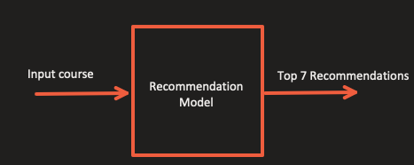

Below is the complete Data Science Lifecycle flow for the Course Recommendation System.

[figure not shown]

Let’s take a closer look at each step. A detailed demonstration of each step is provided later in the document.

Step 0: The Data Source considered for this project is Coursera which is a popular online learning platform. Since Coursera is a trusted source, there are no concerns about the authenticity of the data.

Step 1: The Data is scraped using the requests and beautiful soup libraries and stored in csv file.

Step 2: After retrieving the data, the next step is to clean the data where column refactoring, handling of Null values,data type handling etc are handled in this step.

Step 3: Once the Cleaning is done, Selecting the appropriate features is one of the important steps of the entire lifecycle. Features are selected by analyzing the data and using various data visualizations to gain insights.

Step 4: Building a model based on the features selected

- a) A model is developed using NLTK and TF-IDF techniques.
- b) Another model is developed using Word2Vec

Step 5: Testing the Models and selecting the one that performs the best.

Step 6: Generating the Recommendations

# Part 1 : DATA COLLECTION

The data is extracted from Coursera Website with the help of webscraping using beautifulsoup and requests library. The values extracted from the coursera Website are Course Title,Skills, Ratings,Partner,reviewsCount,level of the course, type of the course, Duration of the course. After scraping the required data, the values are stored in a CSV file. Below is a picture of the Coursera website, with the elements highlighted in red representing the parts to be scraped.

[figure not shown]

```python
import re
import pandas as pd
from bs4 import BeautifulSoup
import requests

# importing the required libraries for scrapping purpose.

response = requests.get("https://www.coursera.org/courses")
html_soup = BeautifulSoup(response.content, 'html.parser')

# Seperate lists for each attribute
course_title = []
course_skills = []
course_ratings = []
course_metaData = []
course_partner = []
course_reviews_count = []

def addAttributes(attributeName, tag, className,element):
    val = element.find(tag,class_=className)
    if val != None:
        attributeName.append(val.get_text(strip = True))
    else:
        attributeName.append(None)
course_title = []
course_skills = []
course_ratings = []
course_metaData = []
course_partner = []
course_reviews_count = []

for i in range(1,100):
    url = "https://www.coursera.org/courses?page=" +str(i)
    page = requests.get(url)
    soup = BeautifulSoup(page.content, 'html.parser')
    elements = soup.find_all('div', class_='cds-ProductCard-content')

    for j in range(0,len(elements)):
        #x = elements[j].find_all('h3', class_='cds-CommonCard-title css-6ecy9b')
        addAttributes(course_title,'h3','cds-CommonCard-title css-6ecy9b',elements[j])
        addAttributes(course_metaData,'div','cds-CommonCard-metadata',elements[j])
        addAttributes(course_ratings,'div','cds-RatingStat-meter',elements[j])
        addAttributes(course_skills,'div','cds-CommonCard-bodyContent',elements[j])
        addAttributes(course_reviews_count,'div','css-vac8rf',elements[j])
        addAttributes(course_partner,'p','cds-ProductCard-partnerNames css-vac8rf',elements[j])
courses_df = pd.DataFrame({'course_title': course_title,
                          'course_organization': course_partner,
                          'course_MetaData': course_metaData,
                          'course_rating':course_ratings,
                           'course_skills':course_skills,
                           'course_reviews_count':course_reviews_count})
courses_df = courses_df.sort_values('course_title')

# here we take each lists we generated by scrapping and made a dataframe out of it is using pandas library.


courses_df.to_csv('Coursera_Courses1.csv')
```

```python
file = 'Coursera_Courses.csv'

df = pd.read_csv(file) # Reading the Scraped data which is stored in CSV file using pandas
df.head()
```

|  | Unnamed: 0 | course_title | course_organization | course_MetaData | course_rating | course_skills | course_reviews_count |
| --- | --- | --- | --- | --- | --- | --- | --- |
| 0 | 1074 | 21st Century Energy Transition: how do we make... | University of Alberta | Beginner · Course · 1 - 3 Months | 4.9Rating, 4.9 out of 5 stars | NaN | 85 reviews |
| 1 | 938 | 3D CAD Fundamental | National Taiwan University | Beginner · Course · 1 - 3 Months | 4.6Rating, 4.6 out of 5 stars | NaN | 611 reviews |
| 2 | 1048 | A Blueprint for Success – Your Video Pre-Produ... | University of Colorado Boulder | Beginner · Course · 1 - 4 Weeks | 4.5Rating, 4.5 out of 5 stars | Skills you'll gain:Leadership and Management | 45 reviews |
| 3 | 973 | A Crash Course in Causality: Inferring Causal... | University of Pennsylvania | Intermediate · Course · 1 - 3 Months | 4.7Rating, 4.7 out of 5 stars | Skills you'll gain:General Statistics, Probabi... | 557 reviews |
| 4 | 916 | A Law Student's Toolkit | Yale University | Mixed · Course · 1 - 3 Months | 4.7Rating, 4.7 out of 5 stars | Skills you'll gain:Writing | 1.5K reviews |

# Part 2 : DATA CLEANING

Removing unwanted columns

```python
df.drop(columns='Unnamed: 0',inplace = True)
df.head()
```

|  | course_title | course_organization | course_MetaData | course_rating | course_skills | course_reviews_count |
| --- | --- | --- | --- | --- | --- | --- |
| 0 | 21st Century Energy Transition: how do we make... | University of Alberta | Beginner · Course · 1 - 3 Months | 4.9Rating, 4.9 out of 5 stars | NaN | 85 reviews |
| 1 | 3D CAD Fundamental | National Taiwan University | Beginner · Course · 1 - 3 Months | 4.6Rating, 4.6 out of 5 stars | NaN | 611 reviews |
| 2 | A Blueprint for Success – Your Video Pre-Produ... | University of Colorado Boulder | Beginner · Course · 1 - 4 Weeks | 4.5Rating, 4.5 out of 5 stars | Skills you'll gain:Leadership and Management | 45 reviews |
| 3 | A Crash Course in Causality: Inferring Causal... | University of Pennsylvania | Intermediate · Course · 1 - 3 Months | 4.7Rating, 4.7 out of 5 stars | Skills you'll gain:General Statistics, Probabi... | 557 reviews |
| 4 | A Law Student's Toolkit | Yale University | Mixed · Course · 1 - 3 Months | 4.7Rating, 4.7 out of 5 stars | Skills you'll gain:Writing | 1.5K reviews |

Splitting the course_MetaData column into 3 different columns - (course_level, type, course_duration)

```python
df[['course_level', 'course_type', 'course_duration']] = df['course_MetaData'].str.split('·', expand=True)
df.drop(columns=['course_MetaData'],inplace=True) # dropping course_MetaData
df.head()
```

|  | course_title | course_organization | course_rating | course_skills | course_reviews_count | course_level | course_type | course_duration |
| --- | --- | --- | --- | --- | --- | --- | --- | --- |
| 0 | 21st Century Energy Transition: how do we make... | University of Alberta | 4.9Rating, 4.9 out of 5 stars | NaN | 85 reviews | Beginner | Course | 1 - 3 Months |
| 1 | 3D CAD Fundamental | National Taiwan University | 4.6Rating, 4.6 out of 5 stars | NaN | 611 reviews | Beginner | Course | 1 - 3 Months |
| 2 | A Blueprint for Success – Your Video Pre-Produ... | University of Colorado Boulder | 4.5Rating, 4.5 out of 5 stars | Skills you'll gain:Leadership and Management | 45 reviews | Beginner | Course | 1 - 4 Weeks |
| 3 | A Crash Course in Causality: Inferring Causal... | University of Pennsylvania | 4.7Rating, 4.7 out of 5 stars | Skills you'll gain:General Statistics, Probabi... | 557 reviews | Intermediate | Course | 1 - 3 Months |
| 4 | A Law Student's Toolkit | Yale University | 4.7Rating, 4.7 out of 5 stars | Skills you'll gain:Writing | 1.5K reviews | Mixed | Course | 1 - 3 Months |

Modifying the course_rating column and removing the unwanted information and sustaining only the rating values in the column.

```python
df['course_rating'] = df['course_rating'].str.extract(r'(\d+\.\d+)')
df.head()
```

|  | course_title | course_organization | course_rating | course_skills | course_reviews_count | course_level | course_type | course_duration |
| --- | --- | --- | --- | --- | --- | --- | --- | --- |
| 0 | 21st Century Energy Transition: how do we make... | University of Alberta | 4.9 | NaN | 85 reviews | Beginner | Course | 1 - 3 Months |
| 1 | 3D CAD Fundamental | National Taiwan University | 4.6 | NaN | 611 reviews | Beginner | Course | 1 - 3 Months |
| 2 | A Blueprint for Success – Your Video Pre-Produ... | University of Colorado Boulder | 4.5 | Skills you'll gain:Leadership and Management | 45 reviews | Beginner | Course | 1 - 4 Weeks |
| 3 | A Crash Course in Causality: Inferring Causal... | University of Pennsylvania | 4.7 | Skills you'll gain:General Statistics, Probabi... | 557 reviews | Intermediate | Course | 1 - 3 Months |
| 4 | A Law Student's Toolkit | Yale University | 4.7 | Skills you'll gain:Writing | 1.5K reviews | Mixed | Course | 1 - 3 Months |

```python
df['course_reviews_count'] = df['course_reviews_count'].str.extract(r'([\d\.K]+)')
df.head()
```

|  | course_title | course_organization | course_rating | course_skills | course_reviews_count | course_level | course_type | course_duration |
| --- | --- | --- | --- | --- | --- | --- | --- | --- |
| 0 | 21st Century Energy Transition: how do we make... | University of Alberta | 4.9 | NaN | 85 | Beginner | Course | 1 - 3 Months |
| 1 | 3D CAD Fundamental | National Taiwan University | 4.6 | NaN | 611 | Beginner | Course | 1 - 3 Months |
| 2 | A Blueprint for Success – Your Video Pre-Produ... | University of Colorado Boulder | 4.5 | Skills you'll gain:Leadership and Management | 45 | Beginner | Course | 1 - 4 Weeks |
| 3 | A Crash Course in Causality: Inferring Causal... | University of Pennsylvania | 4.7 | Skills you'll gain:General Statistics, Probabi... | 557 | Intermediate | Course | 1 - 3 Months |
| 4 | A Law Student's Toolkit | Yale University | 4.7 | Skills you'll gain:Writing | 1.5K | Mixed | Course | 1 - 3 Months |

Converting course_reviews_count into numerical type

```python
def convert_reviews_count(value):
    value = str(value)
    if 'K' in value:
        # Remove 'K', convert to float, and multiply by 1000
        return float(value.replace('K', '').strip()) * 1000
    else:
        # Convert to float
        return float(value)

# Apply the function to the column
df['course_reviews_count'] = df['course_reviews_count'].apply(convert_reviews_count)
df.head()
```

|  | course_title | course_organization | course_rating | course_skills | course_reviews_count | course_level | course_type | course_duration |
| --- | --- | --- | --- | --- | --- | --- | --- | --- |
| 0 | 21st Century Energy Transition: how do we make... | University of Alberta | 4.9 | NaN | 85.0 | Beginner | Course | 1 - 3 Months |
| 1 | 3D CAD Fundamental | National Taiwan University | 4.6 | NaN | 611.0 | Beginner | Course | 1 - 3 Months |
| 2 | A Blueprint for Success – Your Video Pre-Produ... | University of Colorado Boulder | 4.5 | Skills you'll gain:Leadership and Management | 45.0 | Beginner | Course | 1 - 4 Weeks |
| 3 | A Crash Course in Causality: Inferring Causal... | University of Pennsylvania | 4.7 | Skills you'll gain:General Statistics, Probabi... | 557.0 | Intermediate | Course | 1 - 3 Months |
| 4 | A Law Student's Toolkit | Yale University | 4.7 | Skills you'll gain:Writing | 1500.0 | Mixed | Course | 1 - 3 Months |

```python
df['course_skills'] = df['course_skills'].str.replace("Skills you'll gain:", "", regex=False).str.strip()
df.head()
```

|  | course_title | course_organization | course_rating | course_skills | course_reviews_count | course_level | course_type | course_duration |
| --- | --- | --- | --- | --- | --- | --- | --- | --- |
| 0 | 21st Century Energy Transition: how do we make... | University of Alberta | 4.9 | NaN | 85.0 | Beginner | Course | 1 - 3 Months |
| 1 | 3D CAD Fundamental | National Taiwan University | 4.6 | NaN | 611.0 | Beginner | Course | 1 - 3 Months |
| 2 | A Blueprint for Success – Your Video Pre-Produ... | University of Colorado Boulder | 4.5 | Leadership and Management | 45.0 | Beginner | Course | 1 - 4 Weeks |
| 3 | A Crash Course in Causality: Inferring Causal... | University of Pennsylvania | 4.7 | General Statistics, Probability & Statistics, ... | 557.0 | Intermediate | Course | 1 - 3 Months |
| 4 | A Law Student's Toolkit | Yale University | 4.7 | Writing | 1500.0 | Mixed | Course | 1 - 3 Months |

Handling Null Values

```python
df.isna().sum()
```

```
course_title              0
course_organization       0
course_rating            20
course_skills           179
course_reviews_count     13
course_level              0
course_type               0
course_duration           0
dtype: int64
```

Some records have missing information about course skills. This might be because certain organizations didn’t include details about the skills a person would gain from taking the course. Additionally, some values for the features course_reviews_count and course_rating are also missing.

There are various ways to handle Null Scenarios,

1. Can Simply remove the rows that have null value
2. Can replace the Null value with ''.

I am opting for Approach 2 because it ensures that no data is lost. Removing an entire row from the dataset just because one feature has a missing value is not ideal. The other features in that row, which do have valid values, can still provide valuable information and make meaningful contributions to the recommendation system.

```python
df = df.fillna('')
df.isna().sum()
```

```
course_title            0
course_organization     0
course_rating           0
course_skills           0
course_reviews_count    0
course_level            0
course_type             0
course_duration         0
dtype: int64
```

# Part 3: EXPLORATORY DATA ANALYSIS(EDA) AND DATA VISUALIZATION

```python
df['course_rating'].value_counts()
# Here the 'course_rating' column is of type string and this needs to be converted into float for depicting in the graph. This particular change is done in the next cell while plotting the graph.
```

```
course_rating
4.8    363
4.7    350
4.6    217
4.9     85
4.5     79
4.4     33
        20
4.3     15
4.2      9
4.1      6
3.9      5
3.8      2
2.4      1
3.5      1
2.8      1
3.7      1
Name: count, dtype: int64
```

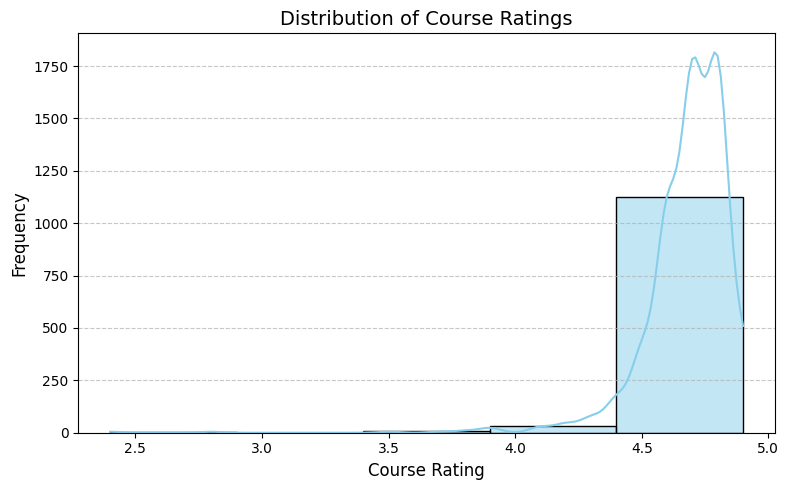

```python
import seaborn as sns
import matplotlib.pyplot as plt
import numpy as np

plt.figure(figsize=(8, 5))
sns.histplot(df['course_rating'].replace('',np.nan).astype(float), bins=5, kde=True, color='skyblue') # changing course_rating to float type for plotting the distribution
plt.title("Distribution of Course Ratings", fontsize=14)
plt.xlabel("Course Rating", fontsize=12)
plt.ylabel("Frequency", fontsize=12)
plt.xticks(fontsize=10)
plt.yticks(fontsize=10)
plt.grid(axis='y', linestyle='--', alpha=0.7)
plt.tight_layout()
plt.show()
```

The majority of course ratings are clustered around the upper range (4.6 to 4.9). This suggests a skewed distribution, with most courses rated highly. There is minimal variation in the course ratings, with only a small number of courses rated below 4.4. This indicates that ratings alone may not provide significant differentiation between courses. Therefore, additional features such as course_skills, course_level, course_type, and course_organization should also be taken into account when building a recommendation system model.

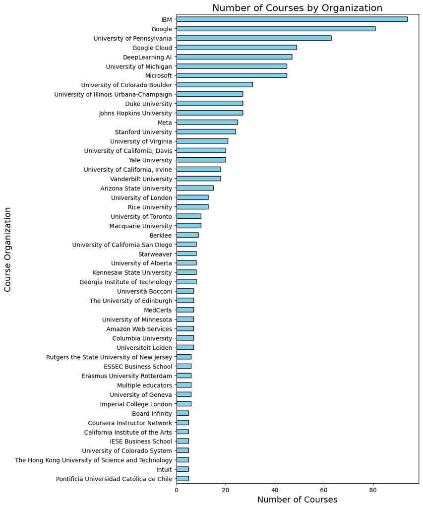

```python
df['course_organization'].value_counts()

organization_counts = df['course_organization'].value_counts().head(50)

# Plot the results
plt.figure(figsize=(10, 12))
organization_counts.sort_values().plot(kind='barh', color='skyblue', edgecolor='black')
plt.title('Number of Courses by Organization', fontsize=16)
plt.xlabel('Number of Courses', fontsize=14)
plt.ylabel('Course Organization', fontsize=14)
plt.tight_layout()
plt.show()
```

Note - There are a total of 187 unique course organizations offering various courses in the dataset. Here, only top 50 are considered for visualization as the plot would look clumsy including all the Organizations.

- Insights from the plot:
1. The plot represents a ranking of organizations based on the number of courses they offer.
2. Most of the courses are offered by IBM and Google.
3. Universities make up a significant portion of the top-ranked organizations
4. The distribution is skewed which indicates that many of the organizations are offering <5 courses.
- Course Organization should be considered as a feature for the recommendation model as
1. Reputation - Some well known organizations like Google, IBM offer many courses and due to the reputation and industry relevence people may prefer these courses which could be a very good parameter for the recommendation system model.
2. Specialization - Specific Organizations offer specalizations in specific domains(eg: specialization in AI, data analysis etc). With the organization known, it could help the recommendation system.

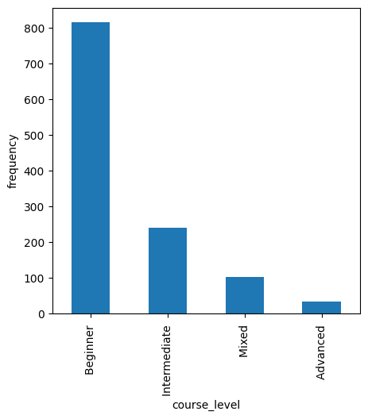

```python
plt.figure(figsize=(5,5))
plt.xlabel('course_level')
plt.ylabel('frequency')
df['course_level'].value_counts().plot(kind='bar')
```

- Insights from the plot
1. The above plot represents the distribution of courses across different levels - beginner,intermediate,mixed and advanced
2. Most of the courses in the dataset are beginner level courses indicating a strong focus for the ones who are new to the subject.
3. There are very few courses which are in advcanced category indicating a limited focus on in-depth learning of the subject.
- Course Level should be considered for the recommendation systems model as
1. The high number of beginner courses indicate that there is a strong demand for introductory courses. Considering this feature ensures that system prioritizes popular level courses.
2. Learners often prefer courses which are suited to their abilities. For example, Beginners prefer introductory courses while learners who are already familiar with the basics prefer a bit more advanced levek of courses.

WORD CLOUD

Using a word cloud to visualize the skills helps identify the most common skill across all the courses in the dataset.

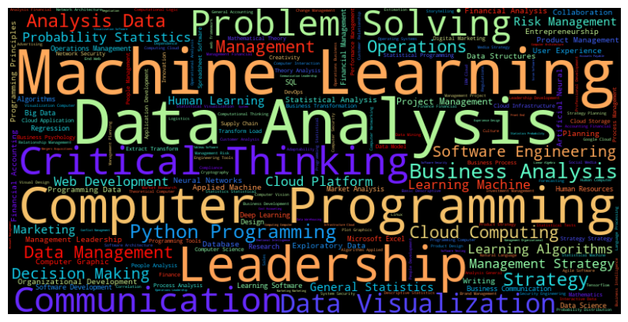

```python
from wordcloud import WordCloud, STOPWORDS
import matplotlib.pyplot as plt

wordcloud = WordCloud(width=800, height=400,
                      background_color='black',
                      colormap='rainbow',
                      stopwords=STOPWORDS,  # Remove common stop words
                      max_words=200).generate(' '.join(df['course_skills'].fillna('') + ' '))

plt.figure(figsize=(10, 10))
plt.imshow(wordcloud, interpolation='bilinear')
plt.axis('off')
plt.show()
```

In the above plot, The words shown in large fonts are the ones that appear most often in the dataset. For example, skills like Machine Learning, Computer Programming, Data Analysis, Critical Thinking, and Leadership are the most common. On the other hand, words with smaller fonts appear less frequently. For instance, skills like DevOps, Network Architecture, and Cryptography are shown in smaller fonts, indicating they occur less often compared to the more common skills. With the help of this word cloud, Most trending skill sets can be known and learners can upskill in those particular areas and build a career.

Creating a column in the dataframe which consists of course_organization, skills,level,duration,type,rating

```python
df['featuresCombined'] = (
    df['course_organization'].fillna('') + ' ' +
    df['course_skills'].fillna('') + ' ' +
    df['course_level'].fillna('') + ' ' +
    df['course_type'].fillna('') + ' ' +
    #df['course_duration'].fillna('') + ' ' +
    df['course_rating'].fillna('').astype(str)
)
df.head()
```

|  | course_title | course_organization | course_rating | course_skills | course_reviews_count | course_level | course_type | course_duration | featuresCombined |
| --- | --- | --- | --- | --- | --- | --- | --- | --- | --- |
| 0 | 21st Century Energy Transition: how do we make... | University of Alberta | 4.9 |  | 85.0 | Beginner | Course | 1 - 3 Months | University of Alberta Beginner Course 4.9 |
| 1 | 3D CAD Fundamental | National Taiwan University | 4.6 |  | 611.0 | Beginner | Course | 1 - 3 Months | National Taiwan University Beginner Course ... |
| 2 | A Blueprint for Success – Your Video Pre-Produ... | University of Colorado Boulder | 4.5 | Leadership and Management | 45.0 | Beginner | Course | 1 - 4 Weeks | University of Colorado Boulder Leadership and ... |
| 3 | A Crash Course in Causality: Inferring Causal... | University of Pennsylvania | 4.7 | General Statistics, Probability & Statistics, ... | 557.0 | Intermediate | Course | 1 - 3 Months | University of Pennsylvania General Statistics,... |
| 4 | A Law Student's Toolkit | Yale University | 4.7 | Writing | 1500.0 | Mixed | Course | 1 - 3 Months | Yale University Writing Mixed Course 4.7 |

```python
df['featuresCombined'][2] # figure a way to handle null values
```

```
'University of Colorado Boulder Leadership and Management Beginner   Course  4.5'
```

# Part 4: MODEL IMPLEMENTATION

NLP - Using NLTK

Approach 1: TF-IDF

The below is the flow chart of TF-IDF approach. All the features are combined in one column and that particular column is passed to word_tokenizer which is an inbuilt function in NLTK module used to convert the corpus into Tokens. These Tokens are then passed to the Stemmer which performs the stemming of the tokens. Then this stemmed output is passed to the TF-IDF Vectorizer which would convert the textal data to numerical representations. This represents the importance of a word in a document relative to a collection of documents. After the vectors are created, the cosine similarity is computed for input vector and all the vectors in the dataset. The top 7 recommendations are determined by selecting the 7 highest Cosine Similarity values.

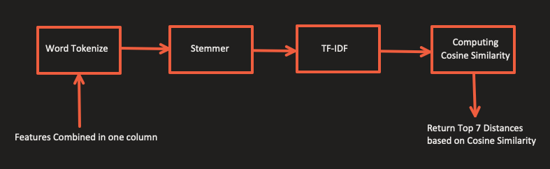

```python
import nltk
from nltk.tokenize import word_tokenize
from nltk.stem import PorterStemmer
from sklearn.feature_extraction.text import TfidfVectorizer
from sklearn.metrics.pairwise import cosine_similarity
from nltk.stem import WordNetLemmatizer
nltk.download('wordnet')
```

```
True
```

```python
stemmer = PorterStemmer()

def token(t):
    token = nltk.word_tokenize(t)
    w = [stemmer.stem(w) for w in token]
    return " ".join(w)
```

```python
df['featuresCombined'].apply(lambda x: token(x)) # converting into tokens along with stemming

tfid = TfidfVectorizer(analyzer='word',stop_words='english')

matrix = tfid.fit_transform(df['featuresCombined'])
```

```python
# Convert the matrix to a dense array
dense_matrix = matrix.toarray()

# Create a DataFrame for better readability
tfidf_df = pd.DataFrame(dense_matrix, columns=tfid.get_feature_names_out())

# Display the DataFrame
(tfidf_df)
```

|  | academy | accelerators | accepted | account | accounting | accounts | accouting | acquisitions | adaptability | administration | ... | western | williams | women | workday | writing | xbox | yale | yonsei | york | école |
| --- | --- | --- | --- | --- | --- | --- | --- | --- | --- | --- | --- | --- | --- | --- | --- | --- | --- | --- | --- | --- | --- |
| 0 | 0.0 | 0.0 | 0.0 | 0.000000 | 0.000000 | 0.0 | 0.0 | 0.0 | 0.00000 | 0.0 | ... | 0.0 | 0.0 | 0.0 | 0.0 | 0.000000 | 0.000000 | 0.000000 | 0.0 | 0.0 | 0.000000 |
| 1 | 0.0 | 0.0 | 0.0 | 0.000000 | 0.000000 | 0.0 | 0.0 | 0.0 | 0.00000 | 0.0 | ... | 0.0 | 0.0 | 0.0 | 0.0 | 0.000000 | 0.000000 | 0.000000 | 0.0 | 0.0 | 0.000000 |
| 2 | 0.0 | 0.0 | 0.0 | 0.000000 | 0.000000 | 0.0 | 0.0 | 0.0 | 0.00000 | 0.0 | ... | 0.0 | 0.0 | 0.0 | 0.0 | 0.000000 | 0.000000 | 0.000000 | 0.0 | 0.0 | 0.000000 |
| 3 | 0.0 | 0.0 | 0.0 | 0.000000 | 0.000000 | 0.0 | 0.0 | 0.0 | 0.00000 | 0.0 | ... | 0.0 | 0.0 | 0.0 | 0.0 | 0.000000 | 0.000000 | 0.000000 | 0.0 | 0.0 | 0.000000 |
| 4 | 0.0 | 0.0 | 0.0 | 0.000000 | 0.000000 | 0.0 | 0.0 | 0.0 | 0.00000 | 0.0 | ... | 0.0 | 0.0 | 0.0 | 0.0 | 0.497244 | 0.000000 | 0.665437 | 0.0 | 0.0 | 0.000000 |
| ... | ... | ... | ... | ... | ... | ... | ... | ... | ... | ... | ... | ... | ... | ... | ... | ... | ... | ... | ... | ... | ... |
| 1183 | 0.0 | 0.0 | 0.0 | 0.000000 | 0.000000 | 0.0 | 0.0 | 0.0 | 0.00000 | 0.0 | ... | 0.0 | 0.0 | 0.0 | 0.0 | 0.000000 | 0.702788 | 0.000000 | 0.0 | 0.0 | 0.000000 |
| 1184 | 0.0 | 0.0 | 0.0 | 0.000000 | 0.000000 | 0.0 | 0.0 | 0.0 | 0.00000 | 0.0 | ... | 0.0 | 0.0 | 0.0 | 0.0 | 0.000000 | 0.000000 | 0.000000 | 0.0 | 0.0 | 0.000000 |
| 1185 | 0.0 | 0.0 | 0.0 | 0.000000 | 0.000000 | 0.0 | 0.0 | 0.0 | 0.00000 | 0.0 | ... | 0.0 | 0.0 | 0.0 | 0.0 | 0.354994 | 0.000000 | 0.000000 | 0.0 | 0.0 | 0.593243 |
| 1186 | 0.0 | 0.0 | 0.0 | 0.119561 | 0.365558 | 0.0 | 0.0 | 0.0 | 0.11365 | 0.0 | ... | 0.0 | 0.0 | 0.0 | 0.0 | 0.093297 | 0.000000 | 0.000000 | 0.0 | 0.0 | 0.000000 |
| 1187 | 0.0 | 0.0 | 0.0 | 0.170635 | 0.000000 | 0.0 | 0.0 | 0.0 | 0.00000 | 0.0 | ... | 0.0 | 0.0 | 0.0 | 0.0 | 0.000000 | 0.000000 | 0.000000 | 0.0 | 0.0 | 0.000000 |

1188 rows × 582 columns

```python
def recommender(name):
    # Get the index of the course with the given title
    idx = df[df['course_title'] == name].index[0]

    # Ensure the matrix is dense
    global matrix
    if not isinstance(matrix, np.ndarray):
        matrix = matrix.toarray()

    # Cosine Similarity
    cosine_sim = cosine_similarity(matrix)

    # Manhattan (L1) and Euclidean (L2) Distances
    manhattan_distances = np.sum(np.abs(matrix - matrix[idx, :]), axis=1)
    euclidean_distances = np.linalg.norm(matrix - matrix[idx, :], axis=1)

    # Compute and sort the cosine similarity in descending order
    distances = sorted(list(enumerate(cosine_sim[idx])), reverse=True, key=lambda x: x[1])

    # Initialize the result list
    coursesList = []

    # Iterate over the top recommendations (excluding the course itself at index 0)
    for n_id in distances[1:8]:
        course_title = df.iloc[n_id[0]].course_title
        cosine_similarity_value = n_id[1]
        manhattan_distance = manhattan_distances[n_id[0]]
        euclidean_distance = euclidean_distances[n_id[0]]

        # Append results with all metrics
        coursesList.append({
            'course_title': course_title,
            'cosine_similarity': cosine_similarity_value,
            'manhattan_distance': manhattan_distance,
            'euclidean_distance': euclidean_distance,
        })

    return coursesList

# Call the function
recommendations = recommender('Big Data')
for rec in recommendations:
    print(rec)
```

```
{'course_title': 'Introduction to Big Data', 'cosine_similarity': 0.7892358642298445, 'manhattan_distance': 3.8752044744963365, 'euclidean_distance': 0.6492520862810615}
{'course_title': 'IBM Data Engineering', 'cosine_similarity': 0.7447169015811044, 'manhattan_distance': 4.634886753855353, 'euclidean_distance': 0.714539149968559}
{'course_title': 'Applied Data Science with Python', 'cosine_similarity': 0.6833726752756475, 'manhattan_distance': 4.794246408792408, 'euclidean_distance': 0.7957729886397911}
{'course_title': 'Business Analytics', 'cosine_similarity': 0.6772403253843424, 'manhattan_distance': 5.589191950431578, 'euclidean_distance': 0.8034421878587877}
{'course_title': 'IBM Data Analyst', 'cosine_similarity': 0.6745651461219382, 'manhattan_distance': 5.666665863587339, 'euclidean_distance': 0.8067649643831365}
{'course_title': 'Data Science', 'cosine_similarity': 0.669926549901383, 'manhattan_distance': 6.064771040235026, 'euclidean_distance': 0.8124942462548481}
{'course_title': 'Learn SQL Basics for Data Science', 'cosine_similarity': 0.6549089779860173, 'manhattan_distance': 5.225286115933362, 'euclidean_distance': 0.8307719566932702}
```

Test Case 1 :

Input : 'Data Analysis with Python'

```python
tc1_model1 = recommender('Data Analysis with Python')
tc1_model1
```

```
[{'course_title': 'Applied Data Science',
  'cosine_similarity': 0.9493486287903148,
  'manhattan_distance': 1.080267873218268,
  'euclidean_distance': 0.31828091746030057},
 {'course_title': 'IBM Data Science',
  'cosine_similarity': 0.7995183366944298,
  'manhattan_distance': 3.4184420907619626,
  'euclidean_distance': 0.6332166506111001},
 {'course_title': 'Data Science: Statistics and Machine Learning',
  'cosine_similarity': 0.7442527047228943,
  'manhattan_distance': 4.250527164253298,
  'euclidean_distance': 0.7151885000153538},
 {'course_title': 'Applied Data Science Capstone',
  'cosine_similarity': 0.7388789892498828,
  'manhattan_distance': 2.773662488079329,
  'euclidean_distance': 0.722663145248348},
 {'course_title': 'IBM Data Analyst',
  'cosine_similarity': 0.7286410051973915,
  'manhattan_distance': 4.525414061501106,
  'euclidean_distance': 0.7366939592566352},
 {'course_title': 'IBM Generative AI Engineering',
  'cosine_similarity': 0.7265389809212695,
  'manhattan_distance': 4.470746805316957,
  'euclidean_distance': 0.7395417758027341},
 {'course_title': 'Applied Data Science with Python',
  'cosine_similarity': 0.7211718116291445,
  'manhattan_distance': 4.276906813575785,
  'euclidean_distance': 0.7467639364228237}]
```

Description of the output: All the recommended courses are related to data science, belong to the same category, and are offered by the same organization. So the returned output seems to be correct. However, a detailed testing analysis is done later in this project to validate the output.

Test Case 2:

Input : 'Financial Management'

```python
tc2_model1 = recommender('Financial Management')
tc2_model1
```

```
[{'course_title': 'Fundamentals of Accounting',
  'cosine_similarity': 0.8697862413037147,
  'manhattan_distance': 2.5053456172623045,
  'euclidean_distance': 0.5103209944658075},
 {'course_title': 'Financial Analysis - Skills for Success',
  'cosine_similarity': 0.8630664683814937,
  'manhattan_distance': 2.696811710597011,
  'euclidean_distance': 0.5233230964108244},
 {'course_title': 'Introduction to Financial Analysis - The "Why?"',
  'cosine_similarity': 0.8401677870736455,
  'manhattan_distance': 3.0215372264292872,
  'euclidean_distance': 0.5653887387034776},
 {'course_title': 'Financial Reporting',
  'cosine_similarity': 0.839194891618156,
  'manhattan_distance': 2.6611381276213852,
  'euclidean_distance': 0.5671068830156163},
 {'course_title': 'Introduction to Finance and Accounting',
  'cosine_similarity': 0.8258051641067883,
  'manhattan_distance': 3.22698325775017,
  'euclidean_distance': 0.5902454335159432},
 {'course_title': 'Introduction to Financial Accounting',
  'cosine_similarity': 0.8123961050155064,
  'manhattan_distance': 3.410132947875062,
  'euclidean_distance': 0.6125420719991297},
 {'course_title': 'Financial Accounting Fundamentals',
  'cosine_similarity': 0.8080912178384737,
  'manhattan_distance': 3.504214552003411,
  'euclidean_distance': 0.6195301157514882}]
```

Desciption of the output - Here all th courses recommended fall under the Finance related category since the input is 'Financial Management'

Test Case 3:

Input :'Introduction to Calculus'

```python
tc3_model1 = recommender('Introduction to Calculus')
tc3_model1
```

```
[{'course_title': 'Algebra: Elementary to Advanced',
  'cosine_similarity': 0.6709975329729639,
  'manhattan_distance': 3.040246168693908,
  'euclidean_distance': 0.8111750329331349},
 {'course_title': 'Mathematics for Machine Learning: Multivariate Calculus',
  'cosine_similarity': 0.6581336633939802,
  'manhattan_distance': 3.3775915994790426,
  'euclidean_distance': 0.8268812933015476},
 {'course_title': 'Mathematics for Engineers',
  'cosine_similarity': 0.6018497285632599,
  'manhattan_distance': 4.826798079254196,
  'euclidean_distance': 0.8923567352093447},
 {'course_title': 'Spacecraft Dynamics and Control',
  'cosine_similarity': 0.5935910138411528,
  'manhattan_distance': 4.1222911152278545,
  'euclidean_distance': 0.9015641809198582},
 {'course_title': 'Digital Signal Processing',
  'cosine_similarity': 0.5864550469401485,
  'manhattan_distance': 3.6680380338145424,
  'euclidean_distance': 0.9094448340167223},
 {'course_title': 'Introduction to Mathematical Thinking',
  'cosine_similarity': 0.5623683066407072,
  'manhattan_distance': 3.9357047199308157,
  'euclidean_distance': 0.9355551222234774},
 {'course_title': 'Mathematics for Machine Learning',
  'cosine_similarity': 0.5453136869889871,
  'manhattan_distance': 5.015429937489445,
  'euclidean_distance': 0.9536103114071418}]
```

Test Case 4:

Input :'Academic English: Writing'

```python
tc4_model1 = recommender('Academic English: Writing')
tc4_model1
```

```
[{'course_title': 'IELTS Preparation',
  'cosine_similarity': 0.9568824773434801,
  'manhattan_distance': 0.3863068209180741,
  'euclidean_distance': 0.29365804145815555},
 {'course_title': 'TOEFL Preparation',
  'cosine_similarity': 0.9568824773434801,
  'manhattan_distance': 0.3863068209180741,
  'euclidean_distance': 0.29365804145815555},
 {'course_title': 'Learn English: Beginning Grammar',
  'cosine_similarity': 0.9491919260211062,
  'manhattan_distance': 0.42762199724643934,
  'euclidean_distance': 0.3187728783284232},
 {'course_title': 'Learn English: Advanced Grammar and Punctuation',
  'cosine_similarity': 0.8547055157519112,
  'manhattan_distance': 0.9137529881257156,
  'euclidean_distance': 0.5390630468657428},
 {'course_title': 'The Pronunciation of American English',
  'cosine_similarity': 0.8294592106085114,
  'manhattan_distance': 0.9158657165627178,
  'euclidean_distance': 0.5840218992323642},
 {'course_title': 'Corporate Communications',
  'cosine_similarity': 0.6826954911015467,
  'manhattan_distance': 1.5392027274216433,
  'euclidean_distance': 0.796623510698063},
 {'course_title': 'Introduction to Cybersecurity & Risk Management',
  'cosine_similarity': 0.6771700903550081,
  'manhattan_distance': 1.9633238070530366,
  'euclidean_distance': 0.8035296007553075}]
```

Test Case 5:

Input : 'Cancer Biology'

```python
tc5_model1 = recommender('Cancer Biology')
tc5_model1
```

```
[{'course_title': 'Linear Algebra from Elementary to Advanced',
  'cosine_similarity': 1.0000000000000002,
  'manhattan_distance': 0.0,
  'euclidean_distance': 0.0},
 {'course_title': 'Sustainable Cities',
  'cosine_similarity': 0.8584759184486606,
  'manhattan_distance': 1.0706348887290236,
  'euclidean_distance': 0.5320227091982813},
 {'course_title': 'Design and Interpretation of Clinical Trials',
  'cosine_similarity': 0.8268084124242687,
  'manhattan_distance': 1.2169183841652695,
  'euclidean_distance': 0.5885432653182454},
 {'course_title': 'Introduction to Systematic Review and Meta-Analysis',
  'cosine_similarity': 0.8268084124242687,
  'manhattan_distance': 1.2169183841652695,
  'euclidean_distance': 0.5885432653182454},
 {'course_title': 'Psychological First Aid',
  'cosine_similarity': 0.8268084124242687,
  'manhattan_distance': 1.2169183841652695,
  'euclidean_distance': 0.5885432653182454},
 {'course_title': 'Patient Safety',
  'cosine_similarity': 0.7827345426976802,
  'manhattan_distance': 1.6745320512890352,
  'euclidean_distance': 0.6591895892720395},
 {'course_title': 'Excellence in Online Teaching',
  'cosine_similarity': 0.7766254027395677,
  'manhattan_distance': 1.8407744526781014,
  'euclidean_distance': 0.6683929940692561}]
```

Description of the Output - In this case there are some courses such as 'Linear Algebra from Elementary to Advanced' and Excellence in Online Teaching' which are not medical or biologically related courses but since they were offered by the same Organization, they are listed in the top recommendations.

Visualizaing the Word Embeddings

Note - For better visualization, a subset of the dataframe is considered.

The flow chart below shows how word embeddings are generated.

As mentioned earlier, a sample dataset is used after applying TF-IDF vectorization to make the data easier to visualize. Then, Principal Component Analysis (PCA) is applied to reduce the multi-dimensional data down to two dimensions. This makes it simpler to visualize and analyze the data in a more manageable space. After that, K-means clustering is used on the reduced data to group similar courses together into different clusters.

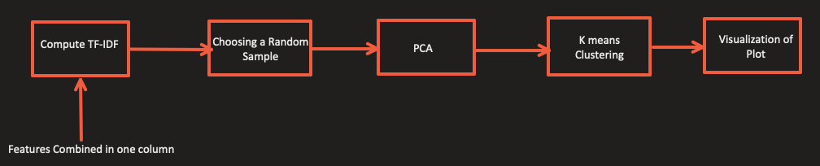

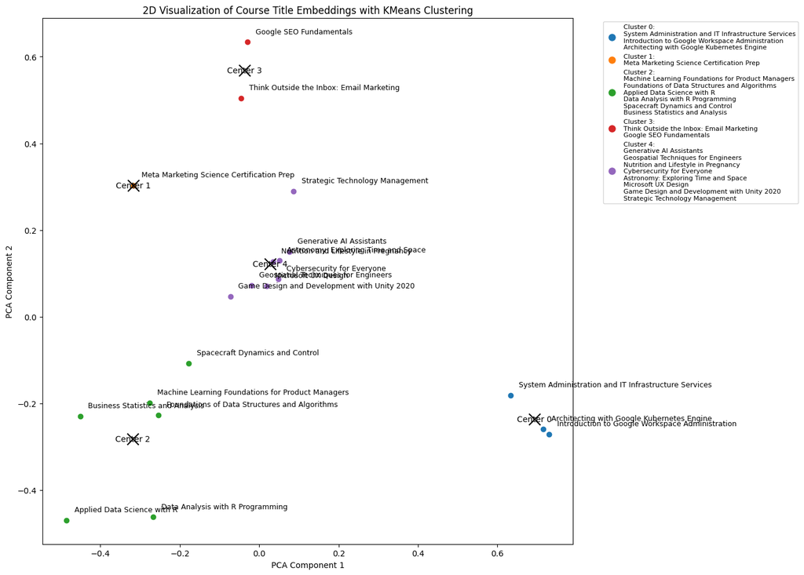

```python
from sklearn.feature_extraction.text import TfidfVectorizer
from sklearn.decomposition import PCA
from sklearn.cluster import KMeans
import matplotlib.pyplot as plt
import pandas as pd

# Assuming 'df' is the original dataset with a 'features_combined' column
# Compute TF-IDF for the entire dataset
vectorizer = TfidfVectorizer()
tfidf_matrix = vectorizer.fit_transform(df['featuresCombined'])

# Take a sample of 20 rows for demonstration
df_sampled = df.sample(n=20, random_state=6).reset_index(drop=True)
tfidf_sampled = vectorizer.transform(df_sampled['featuresCombined'])

# Apply PCA to reduce dimensions to 2D for visualization
pca = PCA(n_components=2)
reduced_embeddings = pca.fit_transform(tfidf_sampled.toarray())

# Apply KMeans clustering
n_clusters = 5
kmeans = KMeans(n_clusters=n_clusters, random_state=42)
labels = kmeans.fit_predict(reduced_embeddings)

# Plot the embeddings and clusters
plt.figure(figsize=(14, 10))

# Initialize a dictionary to store course titles for each cluster
cluster_courses = {i: [] for i in range(n_clusters)}

# Plot data points with cluster colors
for i in range(n_clusters):
    cluster_points = reduced_embeddings[labels == i]
    plt.scatter(cluster_points[:, 0], cluster_points[:, 1], label=f"Cluster {i}")

    # Collect course titles for the legend
    cluster_courses[i] = df_sampled['course_title'][labels == i].tolist()

# Add cluster centers
for i, center in enumerate(kmeans.cluster_centers_):
    plt.scatter(center[0], center[1], marker='x', s=200, color='black', label=f"Center {i}")
    plt.text(center[0], center[1], f"Center {i}", fontsize=10, color='black', ha='center', va='center')

# Annotate individual course titles
for i, title in enumerate(df_sampled['course_title']):
    x, y = reduced_embeddings[i]
    plt.text(x + 0.02, y + 0.02, title, fontsize=9)

# Create a legend with courses listed under each cluster
legend_labels = []
for i in range(n_clusters):
    cluster_label = f"Cluster {i}:\n" + "\n".join(cluster_courses[i])
    legend_labels.append((plt.Line2D([0], [0], marker='o', color='w', markerfacecolor=plt.cm.tab10(i), markersize=10), cluster_label))

# Add the legend outside the plot
plt.legend(*zip(*legend_labels), loc='upper left', bbox_to_anchor=(1.05, 1), fontsize=8)

# Final plot settings
plt.title("2D Visualization of Course Title Embeddings with KMeans Clustering")
plt.xlabel("PCA Component 1")
plt.ylabel("PCA Component 2")
plt.tight_layout()
plt.show()
```

The graph above shows word embeddings after applying PCA and K-means clustering, where similar words are grouped into clusters. For example, courses shown in red are related to marketing, including Think Outside the Inbox: Email Marketing, and Google SEO Fundamentals. Courses related to Data Science are shown in green, such as Data Analysis with R Programming and Applied Data Science with R. Similarly, system administration courses are in blue, and courses related to game design, UX design, and other software technologies are shown in purple. This visualization makes it easier to understand the word embeddings.

```python
from gensim.models import Word2Vec
import gensim
import gensim.downloader as api
```

Approach 2: Word2Vec

The below is the flow chart of Word2Vec approach. All the features are combined in one column and that particular column is passed to word_tokenizer which is an inbuilt function in NLTK module used to convert the corpus into Tokens. This tokenized output is passed to the Word2Vec which captures the semantic relationships between words. After the vectors are created, the cosine similarity is computed for input vector and all the vectors in the dataset. The top 7 recommendations are determined by selecting the 7 highest Cosine Similarity values.

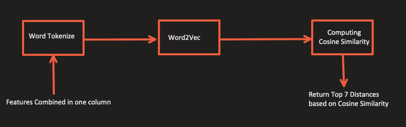

```python
import numpy as np
from scipy.spatial.distance import cosine

df['tokenized_features'] = df['featuresCombined'].apply(lambda x: word_tokenize(x.lower()))

# Step 2: Train the Word2Vec model
model = Word2Vec(
    sentences=df['tokenized_features'].tolist(),  # Tokenized sentences
    vector_size=100,  # Size of word vectors
    window=5,  # Context window size
    min_count=1,  # Minimum word frequency
    sg=0  # Use CBOW (0) or Skip-gram (1)
)

def euclidean_distance(vector1, vector2):
    return np.linalg.norm(vector1 - vector2)

def manhattan_distance(vector1, vector2):
    return np.sum(np.abs(vector1 - vector2))

def recommend_courses(course_title, df, model, top_n=8):

    input_tokens = df[df['course_title'] == course_title]['tokenized_features'].values[0]

    # Compute input vector (filter out-of-vocabulary tokens)
    valid_input_tokens = [token for token in input_tokens if token in model.wv.key_to_index]
    input_vector = model.wv.get_mean_vector(valid_input_tokens, pre_normalize=True, post_normalize=True)

    # Calculate similarities for all courses
    similarities = []
    for i, row in df.iterrows():
        valid_course_tokens = [token for token in row['tokenized_features'] if token in model.wv.key_to_index]
        course_vector = model.wv.get_mean_vector(valid_course_tokens, pre_normalize=True, post_normalize=True)

        # Cosine Similarity
        cosine_sim = 1 - cosine(input_vector, course_vector)

        # Euclidean Distance
        euclidean_dist = euclidean_distance(input_vector, course_vector)

        # Manhattan Distance
        manhattan_dist = manhattan_distance(input_vector, course_vector)


        # Append the similarity measures with descriptive keys
        similarities.append({
            'course_title': row['course_title'],
            'cosine_similarity': cosine_sim,
            'euclidean_distance': euclidean_dist,
            'manhattan_distance': manhattan_dist,
        })

    # Sort by Cosine Similarity and return top_n recommendations
    similarities_sorted = sorted(similarities, key=lambda x: x['cosine_similarity'], reverse=True)  # Sorting by cosine similarity
    return similarities_sorted[1:top_n]
```

```python
df.head()
```

|  | course_title | course_organization | course_rating | course_skills | course_reviews_count | course_level | course_type | course_duration | featuresCombined | tokenized_features |
| --- | --- | --- | --- | --- | --- | --- | --- | --- | --- | --- |
| 0 | 21st Century Energy Transition: how do we make... | University of Alberta | 4.9 |  | 85.0 | Beginner | Course | 1 - 3 Months | University of Alberta Beginner Course 4.9 | [university, of, alberta, beginner, course, 4.9] |
| 1 | 3D CAD Fundamental | National Taiwan University | 4.6 |  | 611.0 | Beginner | Course | 1 - 3 Months | National Taiwan University Beginner Course ... | [national, taiwan, university, beginner, cours... |
| 2 | A Blueprint for Success – Your Video Pre-Produ... | University of Colorado Boulder | 4.5 | Leadership and Management | 45.0 | Beginner | Course | 1 - 4 Weeks | University of Colorado Boulder Leadership and ... | [university, of, colorado, boulder, leadership... |
| 3 | A Crash Course in Causality: Inferring Causal... | University of Pennsylvania | 4.7 | General Statistics, Probability & Statistics, ... | 557.0 | Intermediate | Course | 1 - 3 Months | University of Pennsylvania General Statistics,... | [university, of, pennsylvania, general, statis... |
| 4 | A Law Student's Toolkit | Yale University | 4.7 | Writing | 1500.0 | Mixed | Course | 1 - 3 Months | Yale University Writing Mixed Course 4.7 | [yale, university, writing, mixed, course, 4.7] |

TestCase1

Input - 'Data Analysis with Python'

```python
tc1_model2 = recommend_courses('Data Analysis with Python', df, model)
tc1_model2
```

```
[{'course_title': 'Applied Data Science',
  'cosine_similarity': 0.9998885989189148,
  'euclidean_distance': 0.014928187,
  'manhattan_distance': 0.11579131},
 {'course_title': 'Data Science: Statistics and Machine Learning',
  'cosine_similarity': 0.9982491135597229,
  'euclidean_distance': 0.05917504,
  'manhattan_distance': 0.46979228},
 {'course_title': 'What is Data Science?',
  'cosine_similarity': 0.9981994032859802,
  'euclidean_distance': 0.06000927,
  'manhattan_distance': 0.4760048},
 {'course_title': 'Applied Data Science Capstone',
  'cosine_similarity': 0.9981876611709595,
  'euclidean_distance': 0.060205802,
  'manhattan_distance': 0.46593297},
 {'course_title': 'Foundations of Data Science: K-Means Clustering in Python',
  'cosine_similarity': 0.9980404376983643,
  'euclidean_distance': 0.062603034,
  'manhattan_distance': 0.49295032},
 {'course_title': 'Applied Data Science with Python',
  'cosine_similarity': 0.9980050325393677,
  'euclidean_distance': 0.06316565,
  'manhattan_distance': 0.50102556},
 {'course_title': 'IBM Generative AI Engineering',
  'cosine_similarity': 0.9977181851183832,
  'euclidean_distance': 0.06755517,
  'manhattan_distance': 0.5404034}]
```

TestCase2

Input - 'Financial Management'

```python
tc2_model2 = recommend_courses('Financial Management', df, model)
tc2_model2
```

```
[{'course_title': 'Financial Analysis - Skills for Success',
  'cosine_similarity': 0.9998334050178528,
  'euclidean_distance': 0.018254735,
  'manhattan_distance': 0.14613935},
 {'course_title': 'Fundamentals of Accounting',
  'cosine_similarity': 0.9995958805084229,
  'euclidean_distance': 0.028429745,
  'manhattan_distance': 0.2216028},
 {'course_title': 'Introduction to Finance and Accounting',
  'cosine_similarity': 0.999530017375946,
  'euclidean_distance': 0.030657895,
  'manhattan_distance': 0.24475831},
 {'course_title': 'Fundamentals of Finance',
  'cosine_similarity': 0.9994804859161377,
  'euclidean_distance': 0.03223342,
  'manhattan_distance': 0.247623},
 {'course_title': 'Financial Reporting',
  'cosine_similarity': 0.9994472861289978,
  'euclidean_distance': 0.033247367,
  'manhattan_distance': 0.25425646},
 {'course_title': 'Auditing I: Conceptual Foundations of Auditing',
  'cosine_similarity': 0.9992572069168091,
  'euclidean_distance': 0.038544085,
  'manhattan_distance': 0.31000406},
 {'course_title': 'Introduction to Corporate Finance',
  'cosine_similarity': 0.9991940259933472,
  'euclidean_distance': 0.04014943,
  'manhattan_distance': 0.3230193}]
```

TestCase3

Input - 'Introduction to Calculus'

```python
tc3_model2 = recommend_courses('Introduction to Calculus', df, model)
tc3_model2
```

```
[{'course_title': 'Algebra: Elementary to Advanced',
  'cosine_similarity': 0.9994024038314819,
  'euclidean_distance': 0.034569137,
  'manhattan_distance': 0.264113},
 {'course_title': 'Epidemiology in Public Health Practice',
  'cosine_similarity': 0.9991208910942078,
  'euclidean_distance': 0.041931268,
  'manhattan_distance': 0.33728805},
 {'course_title': 'Systems Biology and Biotechnology',
  'cosine_similarity': 0.9990326166152954,
  'euclidean_distance': 0.04398558,
  'manhattan_distance': 0.36299294},
 {'course_title': 'Excel Skills for Business: Advanced',
  'cosine_similarity': 0.9989080429077148,
  'euclidean_distance': 0.046732534,
  'manhattan_distance': 0.38121763},
 {'course_title': 'ADP Entry-Level Payroll Specialist',
  'cosine_similarity': 0.9982683658599854,
  'euclidean_distance': 0.05885019,
  'manhattan_distance': 0.46807677},
 {'course_title': 'Digital Signal Processing',
  'cosine_similarity': 0.9982120394706726,
  'euclidean_distance': 0.059799373,
  'manhattan_distance': 0.4899603},
 {'course_title': 'Spacecraft Dynamics and Control',
  'cosine_similarity': 0.9981973171234131,
  'euclidean_distance': 0.06004393,
  'manhattan_distance': 0.46142876}]
```

TestCase4

Input - 'Academic English: Writing'

```python
tc4_model2 = recommend_courses('Academic English: Writing', df, model)
tc4_model2
```

```
[{'course_title': 'Wine Tasting: Sensory Techniques for Wine Analysis',
  'cosine_similarity': 0.9995496869087219,
  'euclidean_distance': 0.030011168,
  'manhattan_distance': 0.24439473},
 {'course_title': 'Equine Welfare and Management',
  'cosine_similarity': 0.9993962645530701,
  'euclidean_distance': 0.034749813,
  'manhattan_distance': 0.2932822},
 {'course_title': 'Teach English Now! Second Language Reading, Writing, and Grammar',
  'cosine_similarity': 0.9993473887832547,
  'euclidean_distance': 0.03612716,
  'manhattan_distance': 0.28051764},
 {'course_title': 'Speak English Professionally: In Person, Online & On the Phone',
  'cosine_similarity': 0.9993364810943604,
  'euclidean_distance': 0.036430307,
  'manhattan_distance': 0.29666016},
 {'course_title': 'Learn English: Advanced Grammar and Punctuation',
  'cosine_similarity': 0.9992873668670654,
  'euclidean_distance': 0.037753668,
  'manhattan_distance': 0.2916803},
 {'course_title': 'Generative AI in Marketing',
  'cosine_similarity': 0.9992458820343018,
  'euclidean_distance': 0.038835593,
  'manhattan_distance': 0.30542636},
 {'course_title': 'Mindfulness and Well-being',
  'cosine_similarity': 0.9991918206214905,
  'euclidean_distance': 0.04020502,
  'manhattan_distance': 0.3168425}]
```

TestCase5

Input-'Cancer Biology'

```python
tc5_model2 = recommend_courses('Cancer Biology', df, model)
tc5_model2
```

```
[{'course_title': 'Linear Algebra from Elementary to Advanced',
  'cosine_similarity': 0.9998356997917806,
  'euclidean_distance': 0.018128393,
  'manhattan_distance': 0.15218435},
 {'course_title': 'Design and Interpretation of Clinical Trials',
  'cosine_similarity': 0.9995851516723633,
  'euclidean_distance': 0.028805489,
  'manhattan_distance': 0.22752334},
 {'course_title': 'Introduction to Systematic Review and Meta-Analysis',
  'cosine_similarity': 0.9995712041854858,
  'euclidean_distance': 0.029285815,
  'manhattan_distance': 0.23455133},
 {'course_title': 'Psychological First Aid',
  'cosine_similarity': 0.9995712041854858,
  'euclidean_distance': 0.029285815,
  'manhattan_distance': 0.23455133},
 {'course_title': 'University Teaching',
  'cosine_similarity': 0.9994013905525208,
  'euclidean_distance': 0.034600616,
  'manhattan_distance': 0.2737445},
 {'course_title': 'Marketing Strategy',
  'cosine_similarity': 0.9993804693222046,
  'euclidean_distance': 0.035201605,
  'manhattan_distance': 0.27452567},
 {'course_title': 'Power Electronics',
  'cosine_similarity': 0.9993363618850708,
  'euclidean_distance': 0.036431696,
  'manhattan_distance': 0.28800726}]
```

# Part 5: MODEL ANALYSIS

Comparing the Output of both the Models => (TF-IDF) and (Word2Vec)

1. Cosine Similarity

```python
import plotly.graph_objects as go

def compareCosineSimilarities(tcmodel1, tcmodel2, testCase):
    # Create the figure
    fig = go.Figure()

    # Add Model 1 data with distinct markers for legend
    for item in tcmodel1:
        fig.add_trace(go.Scatter(
            x=[item['cosine_similarity']],
            y=['Model 1'],
            mode='markers',
            marker=dict(symbol='x', size=10, color='blue'),
            text=[f"Course: {item['course_title']}<br>Cosine Similarity: {item['cosine_similarity']}"],  # Hover text
            hoverinfo='text',
            name=f"Model 1 - {item['course_title']}<br>Cosine Similarity: {item['cosine_similarity']:.7f}"  # Course title and Cosine Similarity in the legend
        ))

    # Add Model 2 data with distinct markers for legend
    for item in tcmodel2:
        fig.add_trace(go.Scatter(
            x=[item['cosine_similarity']],
            y=['Model 2'],
            mode='markers',
            marker=dict(symbol='circle', size=10, color='red'),
            text=[f"Course: {item['course_title']}<br>Cosine Similarity: {item['cosine_similarity']}"],  # Hover text
            hoverinfo='text',
            name=f"Model 2 - {item['course_title']}<br>Cosine Similarity: {item['cosine_similarity']:.7f}"  # Course title and Cosine Similarity in the legend
        ))

    # Customize layout
    fig.update_layout(
        title=f'Cosine Similarity Comparison (Model 1 vs Model 2) For Test Case {testCase}',
        xaxis_title='Cosine Similarity',
        yaxis_title='Model',
        yaxis=dict(categoryorder='category ascending'),  # Order categories on y-axis
        legend_title='Models and Courses',
        hovermode='closest',
        xaxis=dict(
            tickmode='linear',
            tick0=0.7,
            dtick=0.05  # Define the tick step
        )
    )

    # Show the plot
    fig.show()
```

```python
compareCosineSimilarities(tc1_model1,tc1_model2,1)
```

[output not shown]

Insights from the plot:

Likewise, generating the comparison plots for the other test cases.

```python
compareCosineSimilarities(tc2_model1,tc2_model2,2)
compareCosineSimilarities(tc3_model1,tc3_model2,3)
compareCosineSimilarities(tc4_model1,tc4_model2,4)
compareCosineSimilarities(tc5_model1,tc5_model2,5)
```

[output not shown]

In general, cosine similarity is a reliable metric for measuring the similarity between vectors, and it works well with both TF-IDF and Word2Vec. However, since Word2Vec tends to produce values close to 1, it's a good idea to consider other similarity metrics as well to capture more variation among the data points and determine which model performs better.

2. Euclidean Distance and Manhatten Distance

```python
import plotly.graph_objects as go

def compareDistances(tcmodel1, tcmodel2, testCase):
    # Create the figure
    fig = go.Figure()

    # Add Model 1 data for Manhattan Distance
    for item in tcmodel1:
        fig.add_trace(go.Scatter(
            x=[item['manhattan_distance']],
            y=['Manhattan Distance'],
            mode='markers',
            marker=dict(symbol='x', size=10, color='blue'),
            text=[f"Course: {item['course_title']}<br>Manhattan Distance: {item['manhattan_distance']}"],  # Hover text
            hoverinfo='text',
            name=f"Model 1 - {item['course_title']}<br>Manhattan Distance: {item['manhattan_distance']:.7f}"  # Course title and Manhattan Distance in the legend
        ))

    # Add Model 2 data for Manhattan Distance
    for item in tcmodel2:
        fig.add_trace(go.Scatter(
            x=[item['manhattan_distance']],
            y=['Manhattan Distance'],
            mode='markers',
            marker=dict(symbol='circle', size=10, color='red'),
            text=[f"Course: {item['course_title']}<br>Manhattan Distance: {item['manhattan_distance']}"],  # Hover text
            hoverinfo='text',
            name=f"Model 2 - {item['course_title']}<br>Manhattan Distance: {item['manhattan_distance']:.7f}"  # Course title and Manhattan Distance in the legend
        ))

    # Add Model 1 data for Euclidean Distance
    for item in tcmodel1:
        fig.add_trace(go.Scatter(
            x=[item['euclidean_distance']],
            y=['Euclidean Distance'],
            mode='markers',
            marker=dict(symbol='x', size=10, color='blue'),
            text=[f"Course: {item['course_title']}<br>Euclidean Distance: {item['euclidean_distance']}"],  # Hover text
            hoverinfo='text',
            name=f"Model 1 - {item['course_title']}<br>Euclidean Distance: {item['euclidean_distance']:.7f}"  # Course title and Euclidean Distance in the legend
        ))

    # Add Model 2 data for Euclidean Distance
    for item in tcmodel2:
        fig.add_trace(go.Scatter(
            x=[item['euclidean_distance']],
            y=['Euclidean Distance'],
            mode='markers',
            marker=dict(symbol='circle', size=10, color='red'),
            text=[f"Course: {item['course_title']}<br>Euclidean Distance: {item['euclidean_distance']}"],  # Hover text
            hoverinfo='text',
            name=f"Model 2 - {item['course_title']}<br>Euclidean Distance: {item['euclidean_distance']:.7f}"  # Course title and Euclidean Distance in the legend
        ))

    # Customize layout
    fig.update_layout(
        title=f'Distance Metric Comparison (Manhattan vs Euclidean) For Test Case {testCase}',
        xaxis_title='Distance Value',
        yaxis_title='Distance Metric',
        yaxis=dict(
            categoryorder='category ascending',  # Order categories on y-axis
            tickmode='array',  # Use an array for custom labels
            tickvals=['Manhattan Distance', 'Euclidean Distance'],
            ticktext=['Manhattan', 'Euclidean']
        ),
        legend_title='Models and Courses with Distances',
        hovermode='closest',
        xaxis=dict(
            tickmode='linear',
            tick0=0.0,
            dtick=0.05,  # Define the tick step
            tickangle=45  # Rotate x-axis ticks to prevent overlap
        ),
        showlegend=True
    )

    # Show the plot
    fig.show()
```

```python
compareDistances(tc1_model1, tc1_model2, 1)
compareDistances(tc2_model1, tc2_model2, 2)
compareDistances(tc3_model1, tc3_model2, 3)
compareDistances(tc4_model1, tc4_model2, 4)
compareDistances(tc5_model1, tc5_model2, 5)
```

[output not shown]

Note - If the distance is less, it indicates that the vectors are similar.

Insights from the plot:

1. For both distance metrics, Model 2 has much smaller distance values than Model 1, which makes sense because Word2Vec looks at the meaning of the words, while TF-IDF focuses on the structure of the words. However, in test case 5, there is one course where Model 1 has a smaller distance value than Model 2. This shows that in some rare cases, the structure of the words might be more important than their meaning.
2. The Euclidean distance values for both models are smaller compared to the Manhattan distance, which is expected because Manhattan distance uses the absolute value of the differences, while Euclidean distance takes the square root of the squared differences. The graph also illustrates this difference.
3. The distance metrics capture some variance in the points, which is reflected in the graph, providing a clearer visualization and better understanding of the models' performance across the test cases.

Manual Testing

In this section, let's evaluate the model's recommendations by visiting the Coursera website and assessing the relevance of the predictions.

Test case : Data Analysis with Python Recommended Courses by our model are - Applied Data Science, Data Science: Statistics and Machine Learning, Applied Data Science with Python, Applied Data Science Capstone, Foundations of Data Science: K-Means.

Now, let's manually test the model's recommendation by visiting the Coursera website and checking the skills, organization, and other details for one of the top recommended courses ('Applied Data Science') based on the input course ('Data Analysis with Python').

Data Analysis with Python

[figure not shown]

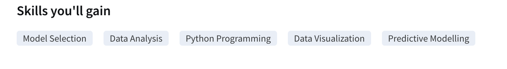

Applied Data Science

[figure not shown]

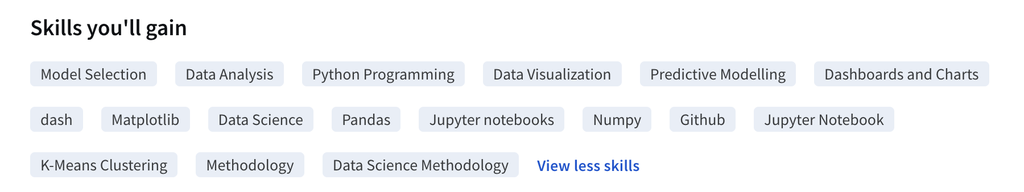

Based on the screenshots of the courses, we can confirm that our model is making accurate recommendations for a given course. The organization offering both courses is the same, and the skills listed in the 'Data Analysis with Python' course are a subset of those in 'Applied Data Science'. Additionally, 'Data Analysis with Python' is part of the 'Applied Data Science' specialization. This suggests that the model recommends the specialization when a course from it is used as input. Through this manual testing, we can conclude that the model is performing well and providing the correct recommendations.

# Part 6: CONCLUSION

REFERENCES:

1. https://www.nltk.org/howto/stem.html
2. https://scikit-learn.org/1.5/modules/generated/sklearn.feature_extraction.text.TfidfVectorizer.html
3. https://radimrehurek.com/gensim/models/word2vec.html